# NumPy and Matplotlib

Reference

- Python for Data Analysis, Wes McKinney
- http://github.com/wesm/pydata-book - Jupyter Notebook files for McKinney's book (in particular, for Ch 04)

Numpy (Numerical Python) is a library used for numerical computations. We will use it here together with Matplotlib library, which is one of the Python's plotting. If you are coming from Matlab, you will notice that their sintax altogether resembles that of Matlab. You can think of the combination of `numpy` and `matplotlib` as Python's version of basic Matlab.

One of the most important `numpy` object types is `ndarray`, which corresponds to Matlab's n-dimensional arrays (vectors, if n=1; matrices, if n = 2, etc.). The speed/efficiency of a code dealing with `numpy` arrays is why `numpy` is very popular. Although `numpy` is written in Python, most of its fast procedures use C, C++ and Fortran codes (don't worry, you don't need to learn yet another language, this is done without Python user being aware of it).

Matplotlib is a basic Python library for ploting 2d and 3d plot. Matplotlib is inspired by ploting features and function names in Matlab. If you have experience with Matlab, you will find a lot of similarity, although, there are a lot of differences, as well.

For someone coming from Matlab, it makes sense to think of the combination of `numpy` and `matplotlib` libraries as a Python version of Matlab (at least basic Matlab for numerical analysis and computation).

```python
import numpy as np
np.random.seed(1234) ## set a seed
import matplotlib.pyplot as plt

#plt.rc('figure', figsize=(10, 6))
plt.rcParams['figure.dpi'] = 150 # default for me was 75
np.set_printoptions(precision=4, suppress=True)
```

```python
##linspace function (just like in Matlab) to create a vector (1D array)
x = np.linspace(start=0, stop=10, num=101)

##print first and last value, the length of x, and increment
x[0], x[-1], len(x), x[1]-x[0]
```

```
(0.0, 10.0, 101, 0.1)
```

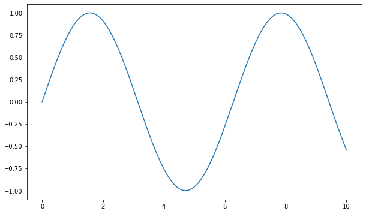

```python
##the following command includes plot into Jupyter nb
%matplotlib inline


##controling size of the figure (withing the nb)

#plt.rcParams['figure.dpi'] = 150  #default is 75
plt.rc('figure', figsize=(10,6))  #controls absolute size of picture
#plt.rcParams['figure.figsize'] = (10,6)  #alternative to the previous


## sequence of num=101 numbers from start=0 to stop=10
x = np.linspace(0, 10, 101)

y = np.sin(x)

plt.plot(x,y)
```

Here is an ilustration of efficiency of a code with numpy array (compared to the same action with a list)

```python
## creating a numpy array from a list, using array() method
li = [-2., 4, 6/3, np.pi]

##setting rounding to a given number of decimal places
%precision 3

np.array(li)
```

```
array([-2.   ,  4.   ,  2.   ,  3.142])
```

```python
## creating a numpy array using arange() method
arr = np.arange(5)

print(arr)
print(type(arr))
```

```
[0 1 2 3 4]
<class 'numpy.ndarray'>
```

```python
arr = np.arange(5)

## creating a list from numpy array
li = list(arr)

print(li)
print(type(li))

[el * 2 for el in li]
```

```
[0, 1, 2, 3, 4]
<class 'list'>
```

```
[0, 2, 4, 6, 8]
```

```python
arr = np.arange(10**5)
li = list(range(10**5))

print('arr: ', type(arr))
print('li: ', type(li))

## doubling array and list components (we do this 100 times for each, to see how long each takes)
%time for bla in range(100): arr2 = arr * 2
%time for bla in range(100): li2 = [el * 2 for el in li]
```

```
arr:  <class 'numpy.ndarray'>
li:  <class 'list'>
Wall time: 8.01 ms
Wall time: 452 ms
```

## The NumPy ndarray: A Multidimensional Array Object

```python
import numpy as np
# Generate some random data
data = np.random.randn(2, 3)
data
```

```
array([[ 0.471, -1.191,  1.433],
       [-0.313, -0.721,  0.887]])
```

```python
print(data * 10);  print('')  ## make one line of space

print(data + data)
```

```
[[  4.714 -11.91   14.327]
 [ -3.127  -7.206   8.872]]

[[ 0.943 -2.382  2.865]
 [-0.625 -1.441  1.774]]
```

```python
data.shape
```

```
(2, 3)
```

```python
a = [1, -5, 7]
b = a
b
b[0] = 2
b
a
```

```
[2, -5, 7]
```

### Creating ndarrays

#### 1D array

```python
data1 = [6, 7.5, 8, 0, 1]
arr1 = np.array(data1)
arr1
```

```
array([6. , 7.5, 8. , 0. , 1. ])
```

#### 2D array (a.k.a. matrix)

```python
data2 = [[1, 2, 3, 4], [5, 6, 7, 8]]
arr2 = np.array(data2)
arr2
```

```
array([[1, 2, 3, 4],
       [5, 6, 7, 8]])
```

```python
## another way (combining lists into a tuple); you can even make one row a list, the other a tuple
np.array( ([1, 2, 3, 4], [5, 6, 7, 8]) )
```

```
array([[1, 2, 3, 4],
       [5, 6, 7, 8]])
```

```python
print(arr2.ndim)
arr2.shape
```

```
2
```

```
(2, 4)
```

```python
print(arr1.dtype)
print(arr2.dtype)
```

```
float64
int32
```

```python
arr2
```

```
array([[1, 2, 3, 4],
       [5, 6, 7, 8]])
```

```python
arr2[1,0:2]
```

```
array([5, 6])
```

#### Slicing 2D Arrays

```python
arr2[1][0:2]
```

```
array([5, 6])
```

```python
np.eye(3)
```

```
array([[1., 0., 0.],
       [0., 1., 0.],
       [0., 0., 1.]])
```

```python
print(np.zeros(10))
print(np.zeros((3, 6)))
np.empty((2, 3, 2))
```

```
[0. 0. 0. 0. 0. 0. 0. 0. 0. 0.]
[[0. 0. 0. 0. 0. 0.]
 [0. 0. 0. 0. 0. 0.]
 [0. 0. 0. 0. 0. 0.]]
```

```
array([[[0., 0.],
        [0., 0.],
        [0., 0.]],

       [[0., 0.],
        [0., 0.],
        [0., 0.]]])
```

```python
np.arange(15)
```

```
array([ 0,  1,  2,  3,  4,  5,  6,  7,  8,  9, 10, 11, 12, 13, 14])
```

### Concatenating Arrays

```python
import numpy as np

a = np.array([1, 2, 3, 4])  ## array of ints
print(a)

b = np.array([5, 6, 7.1])  ## array of floats
print(b)


c = np.concatenate((a,b))  ## must be wrapped in a tuple
print(c)

alltogether = np.concatenate((a,b,c)) ## again, must be wrapped in a tuple
print(alltogether)
```

```
[1 2 3 4]
[5.  6.  7.1]
[1.  2.  3.  4.  5.  6.  7.1]
[1.  2.  3.  4.  5.  6.  7.1 1.  2.  3.  4.  5.  6.  7.1]
```

### Adding Arrays

```python
a = np.linspace(0,1,3)  ##from 0 to 1; 3 points in total - so, 0, 0.5 and 1
print(a)

b = np.array([-1, 0, 1])
print(b)

a + b   ## the two arrays must be of the same length!
```

```
[0.  0.5 1. ]
[-1  0  1]
```

```
array([-1. ,  0.5,  2. ])
```

```python
A = np.array([[1, 2, 3], [4, 5, 6]])
print(A)

B = np.array([[0, 1, 2], [-1, -2, -3]])
print(B)

A + B
```

```
[[1 2 3]
 [4 5 6]]
[[ 0  1  2]
 [-1 -2 -3]]
```

```
array([[1, 3, 5],
       [3, 3, 3]])
```

### Elementwise Multiplication of Arrays

We use the `numpy` function `multiply`

```python
## a and b are from previous cells
print(a)
print(b)

np.multiply(a,b)
```

```
[0.  0.5 1. ]
[-1  0  1]
```

```
array([-0.,  0.,  1.])
```

```python
## A and B are from previous cells
print(A)
print(B)

np.multiply(A,B)
```

```
[[1 2 3]
 [4 5 6]]
[[ 0  1  2]
 [-1 -2 -3]]
```

```
array([[  0,   2,   6],
       [ -4, -10, -18]])
```

### Data Types for ndarrays

```python
arr1 = np.array([1, 2, 3], dtype=np.float64)
arr2 = np.array([1, 2, 3], dtype=np.int32)
arr1.dtype
arr2.dtype
```

```
dtype('int32')
```

```python
arr = np.array([1, 2, 3, 4, 5])
arr.dtype
float_arr = arr.astype(np.float64)
float_arr.dtype
```

```
dtype('float64')
```

```python
arr = np.array([3.7, -1.2, -2.6, 0.5, 12.9, 10.1])
arr
arr.astype(np.int32)
```

```
array([ 3, -1, -2,  0, 12, 10])
```

```python
numeric_strings = np.array(['1.25', '-9.6', '42'], dtype=np.string_)
numeric_strings.astype(float)
```

```
array([ 1.25, -9.6 , 42.  ])
```

```python
int_array = np.arange(10)
calibers = np.array([.22, .270, .357, .380, .44, .50], dtype=np.float64)
int_array.astype(calibers.dtype)
```

```
array([0., 1., 2., 3., 4., 5., 6., 7., 8., 9.])
```

```python
empty_uint32 = np.empty(8, dtype='u4')
empty_uint32
```

```
array([         0, 3221225472,          0, 1074790400,          0,
       1073741824, 1413754136, 1074340347], dtype=uint32)
```

### Arithmetic with NumPy Arrays

```python
arr = np.array([[1., 2., 3.], [4., 5., 6.]])

print(arr, '\n')  ## '\n' means go to new line

print(arr + arr); print('') #can also make new line this way

print(arr - arr)
```

```
[[1. 2. 3.]
 [4. 5. 6.]]

[[ 2.  4.  6.]
 [ 8. 10. 12.]]

[[0. 0. 0.]
 [0. 0. 0.]]
```

```python
## printing arr, 1/arr and arr**2
print(arr,'\n\n',1/arr, '\n\n', arr**2)
```

```
[[1. 2. 3.]
 [4. 5. 6.]]

 [[1.    0.5   0.333]
 [0.25  0.2   0.167]]

 [[ 1.  4.  9.]
 [16. 25. 36.]]
```

```python
arr2 = np.array([[0., 4., 1.], [7., 2., 12.]])
arr2
arr2 > arr  ##we get "boolean masking"
```

```
array([[False,  True, False],
       [ True, False,  True]])
```

#### Dot (inner) product and outer product

Inner product: (vectors must be of the same length)

`arr1` = [1 2 3 4]

`arr2` = [-2 1 0 3]

`arr1` $\bullet$ `arr2` $= 1\cdot (-2) + 2\cdot 1 + 3\cdot 0 + 4\cdot 3 = 12$

```python
arr1 = np.array([1,2,3,4])
arr2 = np.array([-2,1,0,3])

np.dot(arr1,arr2)
```

```
12
```

Outer product:

\begin{align} \vec{x} \otimes \vec{y} &= x \cdot y^{T} = \begin{bmatrix} x_1 \\ x_2\\ \vdots \\ x_m\end{bmatrix} \cdot [y_1 \,\,\, y_2 \,\,\, \dots \,\,\, y_n] \\ &= \left[x_i\,y_j\right]_{ij} \\ &= \begin{bmatrix} x_1y_1 & x_1y_2 & \dots & x_1y_n \\ x_2 y_1 & x_2 y_2 & \dots & x_2y_n \\ x_m y_1 & x_m y_2 & \dots & x_m y_n \end{bmatrix} \end{align}

```python
print(arr1,'\n\n',arr2,'\n')
np.outer(arr1,arr2)
```

```
[1 2 3 4]

 [-2  1  0  3]
```

```
array([[-2,  1,  0,  3],
       [-4,  2,  0,  6],
       [-6,  3,  0,  9],
       [-8,  4,  0, 12]])
```

### More on Indexing and Slicing

```python
arr = np.arange(10)
arr
```

```
array([0, 1, 2, 3, 4, 5, 6, 7, 8, 9])
```

```python
print(arr[5])
print(arr[5:8])
```

```
5
[5 6 7]
```

```python
arr[5:8] = 12
arr
```

```
array([ 0,  1,  2,  3,  4, 12, 12, 12,  8,  9])
```

```python
arr = np.arange(10)
print(arr)
arr[5:8]=[12,12,12]
arr
```

```
[0 1 2 3 4 5 6 7 8 9]
```

```
array([ 0,  1,  2,  3,  4, 12, 12, 12,  8,  9])
```

```python
arr_slice = arr[5:8]
arr_slice
```

```
array([12, 12, 12])
```

**IMPORTANT**: Unlike in lists, a slice of a numpy array is seen as a *view* to the corresponding part of the original numpy array. When the slice is changed, the original np array is changed. Here is an ilustration.

```python
arr_slice[1] = 12345
arr
```

```
array([    0,     1,     2,     3,     4,    12, 12345,    12,     8,
           9])
```

```python
arr_slice[:] = 64
arr
```

```
array([ 0,  1,  2,  3,  4, 64, 64, 64,  8,  9])
```

```python
arr_slice = arr[5:8].copy()
arr_slice[1] = 12
arr_slice
arr
```

```
array([ 0,  1,  2,  3,  4, 64, 64, 64,  8,  9])
```

```python
arr2d = np.array([[1, 2, 3], [4, 5, 6], [7, 8, 9]])
arr2d[2]
```

```
array([7, 8, 9])
```

```python
print(arr2d[0][2])

arr2d[0, 2]
```

```
3
```

```
3
```

```python
arr3d = np.array([[[1, 2, 3], [4, 5, 6]], [[7, 8, 9], [10, 11, 12]]])
arr3d
```

```
array([[[ 1,  2,  3],
        [ 4,  5,  6]],

       [[ 7,  8,  9],
        [10, 11, 12]]])
```

```python
arr3d[0]
```

```
array([[1, 2, 3],
       [4, 5, 6]])
```

```python
old_values = arr3d[0].copy()
arr3d[0] = 42
arr3d
arr3d[0] = old_values
arr3d
```

```
array([[[ 1,  2,  3],
        [ 4,  5,  6]],

       [[ 7,  8,  9],
        [10, 11, 12]]])
```

```python
arr3d[1, 0]
```

```
array([7, 8, 9])
```

```python
x = arr3d[1]
x
x[0]
```

```
array([7, 8, 9])
```

#### Indexing with slices

```python
arr
arr[1:6]
```

```
array([ 1,  2,  3,  4, 64])
```

```python
arr2d
arr2d[:2]
```

```
array([[1, 2, 3],
       [4, 5, 6]])
```

```python
arr2d[:2, 1:]
```

```
array([[2, 3],
       [5, 6]])
```

```python
arr2d[1, :2]
```

```
array([4, 5])
```

```python
arr2d[:2, 2]
```

```
array([3, 6])
```

```python
arr2d[:, :1]
```

```
array([[1],
       [4],
       [7]])
```

```python
arr2d[:2, 1:] = 0
arr2d
```

```
array([[1, 0, 0],
       [4, 0, 0],
       [7, 8, 9]])
```

### Boolean Indexing (a.k.a. Boolean Masking)

```python
names = np.array(['Mary', 'Bob', 'Jane', 'Mary', 'Bob', 'Jane', 'Jane'])
data = np.arange(28).reshape(7,4)
print(names)
data
```

```
['Mary' 'Bob' 'Jane' 'Mary' 'Bob' 'Jane' 'Jane']
```

```
array([[ 0,  1,  2,  3],
       [ 4,  5,  6,  7],
       [ 8,  9, 10, 11],
       [12, 13, 14, 15],
       [16, 17, 18, 19],
       [20, 21, 22, 23],
       [24, 25, 26, 27]])
```

```python
names == 'Bob'
```

```
array([False,  True, False, False,  True, False, False])
```

```python
data[names == 'Bob']
```

```
array([[ 4,  5,  6,  7],
       [16, 17, 18, 19]])
```

```python
print(data[names == 'Bob', 2:])
data[names == 'Bob', 3]
```

```
[[ 6  7]
 [18 19]]
```

```
array([ 7, 19])
```

```python
names != 'Bob'
```

```
array([ True, False,  True,  True, False,  True,  True])
```

```python
data[~(names == 'Bob')]
```

```
array([[ 0,  1,  2,  3],
       [ 8,  9, 10, 11],
       [12, 13, 14, 15],
       [20, 21, 22, 23],
       [24, 25, 26, 27]])
```

```python
cond = names == 'Bob'
data[~cond]
```

```
array([[ 0,  1,  2,  3],
       [ 8,  9, 10, 11],
       [12, 13, 14, 15],
       [20, 21, 22, 23],
       [24, 25, 26, 27]])
```

```python
mask = (names == 'Bob') | (names == 'Jane')
mask
data[mask]
```

```
array([[ 4,  5,  6,  7],
       [ 8,  9, 10, 11],
       [16, 17, 18, 19],
       [20, 21, 22, 23],
       [24, 25, 26, 27]])
```

```python
data < 5
```

```
array([[ True,  True,  True,  True],
       [ True, False, False, False],
       [False, False, False, False],
       [False, False, False, False],
       [False, False, False, False],
       [False, False, False, False],
       [False, False, False, False]])
```

```python
data[data < 5] = 0
data
```

```
array([[ 0,  0,  0,  0],
       [ 0,  5,  6,  7],
       [ 8,  9, 10, 11],
       [12, 13, 14, 15],
       [16, 17, 18, 19],
       [20, 21, 22, 23],
       [24, 25, 26, 27]])
```

```python
data[names != 'Jane'] = 7
data
```

```
array([[ 7,  7,  7,  7],
       [ 7,  7,  7,  7],
       [ 8,  9, 10, 11],
       [ 7,  7,  7,  7],
       [ 7,  7,  7,  7],
       [20, 21, 22, 23],
       [24, 25, 26, 27]])
```

### Fancy Indexing

```python
arr = np.empty((8, 4))
for i in range(8):
    arr[i] = i
arr
```

```
array([[0., 0., 0., 0.],
       [1., 1., 1., 1.],
       [2., 2., 2., 2.],
       [3., 3., 3., 3.],
       [4., 4., 4., 4.],
       [5., 5., 5., 5.],
       [6., 6., 6., 6.],
       [7., 7., 7., 7.]])
```

```python
arr[[4, 3, 0, 6]]
```

```
array([[4., 4., 4., 4.],
       [3., 3., 3., 3.],
       [0., 0., 0., 0.],
       [6., 6., 6., 6.]])
```

```python
arr[[-3, -5, -7]]
```

```
array([[5., 5., 5., 5.],
       [3., 3., 3., 3.],
       [1., 1., 1., 1.]])
```

```python
arr = np.arange(32).reshape((8, 4))
arr
arr[[1, 5, 7, 2], [0, 3, 1, 2]]
```

```
array([ 4, 23, 29, 10])
```

```python
arr[[1, 5, 7, 2]][:, [0, 3, 1, 2]]
```

```
array([[ 4,  7,  5,  6],
       [20, 23, 21, 22],
       [28, 31, 29, 30],
       [ 8, 11,  9, 10]])
```

### Transposing Arrays and Swapping Axes

```python
arr = np.arange(15).reshape((3, 5))
print(arr)
arr.T
```

```
[[ 0  1  2  3  4]
 [ 5  6  7  8  9]
 [10 11 12 13 14]]
```

```
array([[ 0,  5, 10],
       [ 1,  6, 11],
       [ 2,  7, 12],
       [ 3,  8, 13],
       [ 4,  9, 14]])
```

```python
arr = np.random.randn(6, 3)
arr
np.dot(arr.T, arr)
```

```
array([[ 8.853, -7.223, -3.16 ],
       [-7.223,  8.408,  2.344],
       [-3.16 ,  2.344,  1.527]])
```

```python
arr = np.arange(16).reshape((2, 2, 4))
arr
arr.transpose((1, 0, 2))
```

```
array([[[ 0,  1,  2,  3],
        [ 8,  9, 10, 11]],

       [[ 4,  5,  6,  7],
        [12, 13, 14, 15]]])
```

```python
arr
arr.swapaxes(1, 2)
```

```
array([[[ 0,  4],
        [ 1,  5],
        [ 2,  6],
        [ 3,  7]],

       [[ 8, 12],
        [ 9, 13],
        [10, 14],
        [11, 15]]])
```

```python
points = np.arange(-5, 5, 0.01) # 1000 equally spaced points
xs, ys = np.meshgrid(points, points)
ys
```

```
array([[-5.  , -5.  , -5.  , ..., -5.  , -5.  , -5.  ],
       [-4.99, -4.99, -4.99, ..., -4.99, -4.99, -4.99],
       [-4.98, -4.98, -4.98, ..., -4.98, -4.98, -4.98],
       ...,
       [ 4.97,  4.97,  4.97, ...,  4.97,  4.97,  4.97],
       [ 4.98,  4.98,  4.98, ...,  4.98,  4.98,  4.98],
       [ 4.99,  4.99,  4.99, ...,  4.99,  4.99,  4.99]])
```

```python
z = np.sqrt(xs ** 2 + ys ** 2)
z
```

```
array([[7.071, 7.064, 7.057, ..., 7.05 , 7.057, 7.064],
       [7.064, 7.057, 7.05 , ..., 7.043, 7.05 , 7.057],
       [7.057, 7.05 , 7.043, ..., 7.036, 7.043, 7.05 ],
       ...,
       [7.05 , 7.043, 7.036, ..., 7.029, 7.036, 7.043],
       [7.057, 7.05 , 7.043, ..., 7.036, 7.043, 7.05 ],
       [7.064, 7.057, 7.05 , ..., 7.043, 7.05 , 7.057]])
```

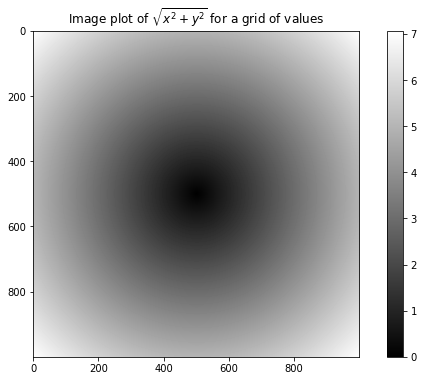

```python
import matplotlib.pyplot as plt
plt.imshow(z, cmap=plt.cm.gray); plt.colorbar()
plt.title("Image plot of $\sqrt{x^2 + y^2}$ for a grid of values")
```

```python
plt.draw()
```

```python
plt.close('all')
```

#### Important!

In Jupyter notebooks plots are reset after each cell is evaluated, so for more complex plots you must put all the plotting commancd in a single cell!!!

### Expressing Conditional Logic as Array Operations

```python
xarr = np.array([1.1, 1.2, 1.3, 1.4, 1.5])
yarr = np.array([2.1, 2.2, 2.3, 2.4, 2.5])
cond = np.array([True, False, True, True, False])
```

```python
result = [(x if c else y)
          for x, y, c in zip(xarr, yarr, cond)]
result
```

```
[1.1, 2.2, 1.3, 1.4, 2.5]
```

```python
result = np.where(cond, xarr, yarr)
result
```

```
array([1.1, 2.2, 1.3, 1.4, 2.5])
```

```python
arr = np.random.randn(4, 4)
arr
arr > 0
np.where(arr > 0, 2, -2)
```

```
array([[ 2, -2,  2, -2],
       [-2,  2, -2,  2],
       [ 2,  2,  2, -2],
       [ 2, -2,  2,  2]])
```

```python
np.where(arr > 0, 2, arr) # set only positive values to 2
```

```
array([[ 2.   , -0.469,  2.   , -1.817],
       [-0.183,  2.   , -0.398,  2.   ],
       [ 2.   ,  2.   ,  2.   , -0.122],
       [ 2.   , -0.323,  2.   ,  2.   ]])
```

### Mathematical and Statistical Methods

```python
arr = np.random.randn(5, 4)
arr
arr.mean()
np.mean(arr)
arr.sum()
```

```
-2.69691997337904
```

```python
arr.mean(axis=1)
arr.sum(axis=0)
```

```
array([ 0.031, -1.385,  0.758, -2.101])
```

```python
arr = np.array([0, 1, 2, 3, 4, 5, 6, 7])
arr.cumsum()
```

```
array([ 0,  1,  3,  6, 10, 15, 21, 28], dtype=int32)
```

```python
arr = np.array([[0, 1, 2], [3, 4, 5], [6, 7, 8]])
arr
arr.cumsum(axis=0)
arr.cumprod(axis=1)
```

```
array([[  0,   0,   0],
       [  3,  12,  60],
       [  6,  42, 336]], dtype=int32)
```

### Methods for Boolean Arrays

```python
arr = np.random.randn(100)
(arr > 0).sum() # Number of positive values
```

```
56
```

```python
bools = np.array([False, False, True, False])
bools.any()
bools.all()
```

```
False
```

### Sorting

```python
arr = np.random.randn(6)
arr
arr.sort()
arr
```

```
array([-0.916, -0.86 , -0.744, -0.32 ,  0.226,  0.537])
```

```python
arr = np.random.randn(5, 3)
arr
arr.sort(1)
arr
```

```
array([[ 0.186,  0.629,  0.952],
       [-0.551, -0.073,  0.988],
       [-1.239, -0.938,  0.14 ],
       [-0.223,  0.122,  2.124],
       [-2.148, -1.409,  1.423]])
```

```python
large_arr = np.random.randn(1000)
large_arr.sort()
large_arr[int(0.05 * len(large_arr))] # 5% quantile
```

```
-1.5861747502442867
```

### Unique and Other Set Logic

```python
names = np.array(['Bob', 'Joe', 'Will', 'Bob', 'Will', 'Joe', 'Joe'])
np.unique(names)
ints = np.array([3, 3, 3, 2, 2, 1, 1, 4, 4])
np.unique(ints)
```

```
array([1, 2, 3, 4])
```

```python
sorted(set(names))
```

```
['Bob', 'Joe', 'Will']
```

```python
values = np.array([6, 0, 0, 3, 2, 5, 6])
np.in1d(values, [2, 3, 6])
```

```
array([ True, False, False,  True,  True, False,  True])
```

## File Input and Output with Arrays

```python
arr = np.arange(10)
np.save('some_array', arr)
```

```python
np.load('some_array.npy')
```

```
array([0, 1, 2, 3, 4, 5, 6, 7, 8, 9])
```

```python
np.savez('array_archive.npz', a=arr, b=arr)
```

```python
arch = np.load('array_archive.npz')
arch['b']
```

```
array([0, 1, 2, 3, 4, 5, 6, 7, 8, 9])
```

```python
np.savez_compressed('arrays_compressed.npz', a=arr, b=arr)
```

```python
!rm some_array.npy
!rm array_archive.npz
!rm arrays_compressed.npz
```

```
rm: cannot remove 'array_archive.npz': Device or resource busy
```

## Linear Algebra

```python
x = np.array([[1., 2., 3.], [4., 5., 6.]])
y = np.array([[6., 23.], [-1, 7], [8, 9]])
x
y
x.dot(y)
```

```
array([[ 28.,  64.],
       [ 67., 181.]])
```

```python
np.dot(x, y)
```

```
array([[ 28.,  64.],
       [ 67., 181.]])
```

```python
np.dot(x, np.ones(3))
```

```
array([ 6., 15.])
```

```python
x @ np.ones(3)
```

```
array([ 6., 15.])
```

```python
from numpy.linalg import inv, qr
X = np.random.randn(5, 5)
mat = X.T.dot(X)
inv(mat)
mat.dot(inv(mat))
q, r = qr(mat)
r
```

```
array([[ -5.617,   4.101,   7.651,   2.471,  -3.919],
       [  0.   , -13.775,  -1.647,   1.663,  -3.835],
       [  0.   ,   0.   ,  -6.973,  -0.61 ,  -0.17 ],
       [  0.   ,   0.   ,   0.   ,  -2.385,   1.268],
       [  0.   ,   0.   ,   0.   ,   0.   ,   0.   ]])
```

## Pseudorandom Number Generation

```python
samples = np.random.normal(size=(4, 4))
samples
```

```
array([[ 1.875,  1.593,  2.296, -1.21 ],
       [ 1.458, -0.161,  0.201,  0.386],
       [ 0.382, -0.652, -1.488,  1.517],
       [-0.229,  0.164,  1.497, -0.599]])
```

```python
from random import normalvariate
N = 1000000
%timeit samples = [normalvariate(0, 1) for _ in range(N)]
%timeit np.random.normal(size=N)
```

```
721 ms ± 25.7 ms per loop (mean ± std. dev. of 7 runs, 1 loop each)
25.4 ms ± 197 µs per loop (mean ± std. dev. of 7 runs, 10 loops each)
```

```python
np.random.seed(1234)
```

```python
rng = np.random.RandomState(1234)
rng.randn(10)
```

```
array([ 0.471, -1.191,  1.433, -0.313, -0.721,  0.887,  0.86 , -0.637,
        0.016, -2.243])
```

## Example: Random Walks

```python
import random
position = 0
walk = [position]
steps = 1000
for i in range(steps):
    step = 1 if random.randint(0, 1) else -1
    position += step
    walk.append(position)
```

```python
plt.figure()
```

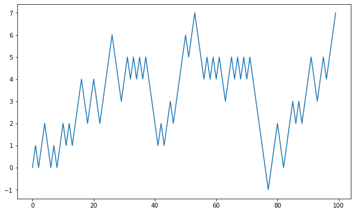

```python
plt.plot(walk[:100])
```

```python
np.random.seed(12345)
```

```python
nsteps = 1000
draws = np.random.randint(0, 2, size=nsteps)
steps = np.where(draws > 0, 1, -1)
walk = steps.cumsum()
```

```python
walk.min()
walk.max()
```

```
31
```

```python
(np.abs(walk) >= 10).argmax()
```

```
37
```

### Simulating Many Random Walks at Once

```python
nwalks = 5000
nsteps = 1000
draws = np.random.randint(0, 2, size=(nwalks, nsteps)) # 0 or 1
steps = np.where(draws > 0, 1, -1)
walks = steps.cumsum(1)
walks
```

```
array([[  1,   0,   1, ...,   8,   7,   8],
       [  1,   0,  -1, ...,  34,  33,  32],
       [  1,   0,  -1, ...,   4,   5,   4],
       ...,
       [  1,   2,   1, ...,  24,  25,  26],
       [  1,   2,   3, ...,  14,  13,  14],
       [ -1,  -2,  -3, ..., -24, -23, -22]], dtype=int32)
```

```python
walks.max()
walks.min()
```

```
-133
```

```python
hits30 = (np.abs(walks) >= 30).any(1)
hits30
hits30.sum() # Number that hit 30 or -30
```

```
3410
```

```python
crossing_times = (np.abs(walks[hits30]) >= 30).argmax(1)
crossing_times.mean()
```

```
498.8897360703812
```

```python
steps = np.random.normal(loc=0, scale=0.25,
                         size=(nwalks, nsteps))
```

Some useful commands that set defaults

```python
import numpy as np
import pandas as pd
PREVIOUS_MAX_ROWS = pd.options.display.max_rows
pd.options.display.max_rows = 20
np.random.seed(12345)
import matplotlib.pyplot as plt
import matplotlib
plt.rc('figure', figsize=(10, 6))  #fig size (width,height)
np.set_printoptions(precision=4, suppress=True)  #<= 4 decimals
```

```python
#this enables interactive use of matplotlib
##%matplotlib notebook
%matplotlib inline
```

### Figures and Subplots

```python
plt.close('all')
#creating a new blank figure
fig = plt.figure()
```

```python
#creating an axis object (that is, a window within the figure where a graph will be created);
#first 2 means there are 2 rows of axes, second 2 means there are 2 columns of axes (so, 4 graphs in total),
#while the number 1 means that ax1 is the the 1st of these 4 axes.
ax1 = fig.add_subplot(2, 2, 1)
```

```python
#ax2 is the 2nd of the 4 axes, which by convention is the 2nd axis in the 1st row
#ax3 is the 3rd of the 4 axes, which by convention is the 1st axis in the 2nd row
#(so, by convention, the enumeration is done row-wise)
ax2 = fig.add_subplot(2, 2, 2)
ax3 = fig.add_subplot(2, 2, 3)
```

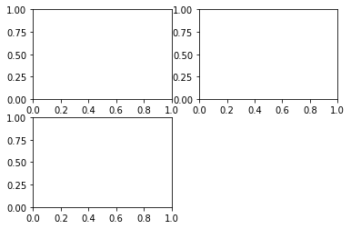

```python
fig = plt.figure()
ax1 = fig.add_subplot(2, 2, 1)
ax2 = fig.add_subplot(2, 2, 2)
ax3 = fig.add_subplot(2, 2, 3)
```

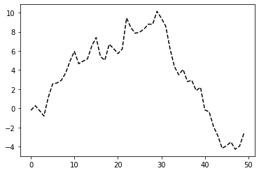

```python
plt.plot(np.random.randn(50).cumsum(), 'k--')
```

```python
ax1.hist(np.random.randn(100), bins=20, color='r', alpha=1)
ax2.scatter(np.arange(30), np.arange(30) + 3 * np.random.randn(30), color=[140/255,29/255,64/255])
```

```python
plt.close('all')
```

The matlab method plt.subplots (not 's' at the end) creates a tuple, whose first component is a new figure and the 2nd one is a numpy array containing the created subplot objects. This is convenient, as it creates nice indexing for easier access of each subplot. If the created numpy array of subplots is called axes, then, for example, axes[0,1] means subplot in the 1st row and 2nd column.

[output not shown]

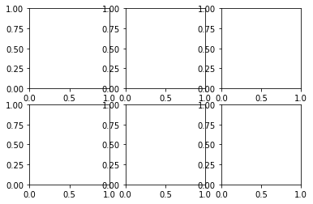

```python
fig, axes = plt.subplots(2, 3)
axes
```

#### Adjusting the spacing around subplots

subplots_adjust(left=None, bottom=None, right=None, top=None, wspace=None, hspace=None)

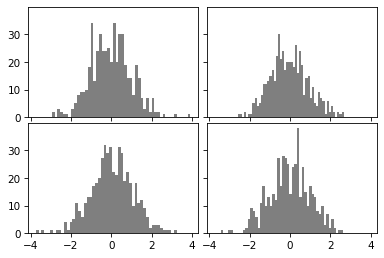

```python
plt.rcParams['figure.dpi'] = 75 ## fig. size


#sharex=True means that all subplots have the same x-axis, which is convenient when we compare data on the same scale.
#Similarly for sharey=True
fig, axes = plt.subplots(2, 2, sharex=True, sharey=True)
for i in range(2):
    for j in range(2):
        #accessing (i,j)-subplot (convenient indexing)
        axes[i, j].hist(np.random.randn(500), bins=50, color='k', alpha=0.5)
plt.subplots_adjust(wspace=0.05, hspace=0.05) #controlling spacing between subplots - width-space and height-space
```

### Colors, Markers, and Line Styles

`ax.plot(x, y, 'g--')`

`ax.plot(x, y, linestyle='--', color='g')`

```python
plt.figure()
```

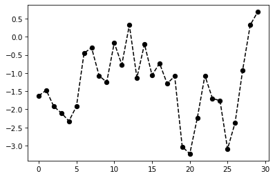

```python
from numpy.random import randn
plt.plot(randn(30).cumsum(), 'ko--')
```

plot(randn(30).cumsum(), color='k', linestyle='dashed', marker='o')

```python
plt.close('all')
```

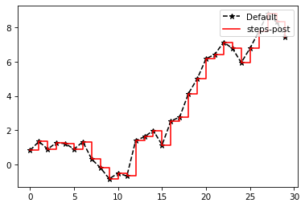

```python
data = np.random.randn(30).cumsum()
plt.plot(data, 'k*--', label='Default')
plt.plot(data, 'r-', drawstyle='steps-post', label='steps-post')
plt.legend(loc='upper right')   #see also plt.legend(loc='best')
```

# 3D Plotting with Matplotlib

The following code snippet enables larger figure in the notebook, as well as prevents autoscroll to turn on

```python
%%html
<style>
.output_wrapper, .output {
    height:auto !important;
    max-height:1000px;  /* your desired max-height here */
}
.output_scroll {
    box-shadow:none !important;
    webkit-box-shadow:none !important;
}
</style>
```

As mentioned above, plots in Jupyter notebooks get reset after cell that has some plotting commands. So, for complex plotting (more than one plot or for adjusting figure features) all the commands regarding the plot need to be in a single cell.

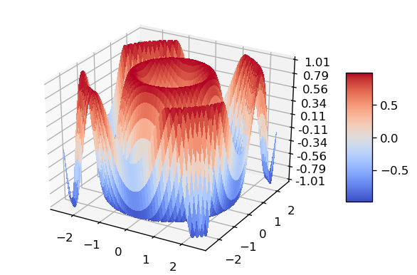

```python
#Demonstrates plotting a 3D surface colored with the coolwarm color map.
#The surface is made opaque by using antialiased=False.

#Also demonstrates using the LinearLocator and custom formatting for the
#z axis tick labels.

%matplotlib inline
plt.rcParams['figure.dpi'] = 120 # default for me was 75

from mpl_toolkits.mplot3d import Axes3D
import matplotlib.pyplot as plt
from matplotlib import cm
from matplotlib.ticker import LinearLocator, FormatStrFormatter
import numpy as np


fig = plt.figure()
ax = fig.gca(projection='3d')

# Make data.
x = np.arange(-2.5, 2.5, 0.01)
y = np.arange(-2.5, 2.5, 0.01)
X, Y = np.meshgrid(x, y)
Z = np.sin(X**2 + Y**2)

# Plot the surface.
surf = ax.plot_surface(X, Y, Z, cmap=cm.coolwarm,
                       linewidth=0, antialiased=False)

# Customize the z axis.
ax.set_zlim(-1.01, 1.01)
ax.zaxis.set_major_locator(LinearLocator(10))
ax.zaxis.set_major_formatter(FormatStrFormatter('%.02f'))

# Add a color bar which maps values to colors.
fig.colorbar(surf, shrink=0.5, aspect=5)

plt.show()
```

```python
names = np.array(['Mary', 'Bob', 'Jane', 'Mary', 'Bob', 'Jane', 'Jane'])
data = np.arange(28).reshape(7,4)
print(names)
data
```

```
['Mary' 'Bob' 'Jane' 'Mary' 'Bob' 'Jane' 'Jane']
```

```
array([[ 0,  1,  2,  3],
       [ 4,  5,  6,  7],
       [ 8,  9, 10, 11],
       [12, 13, 14, 15],
       [16, 17, 18, 19],
       [20, 21, 22, 23],
       [24, 25, 26, 27]])
```